# Exercise 1

## punto 1

1. For $i = 1, \ldots, n$, let $Y_i$ be i.i.d. random variables taking values in $\{1, 2, \ldots, p, p+1\}$ with probabilities $\pi_1, \ldots, \pi_p, \pi_{p+1} > 0$, $\sum_{j=1}^{p+1} \pi_j = 1$. If we code $Y_i$ via the one-hot vector $Y_i = (Y_{i1}, \ldots, Y_{i, p+1})$ where $Y_{ij} = 1$ when $Y_i = j$, then $\sum_{i=1}^{n} Y_i$ has multinomial distribution, $\text{Multinomial}(n, \pi_1, \ldots, \pi_{p+1})$, and the multivariate Central Limit Theorem (CLT) implies
   $$\sqrt{n}(\hat{\pi} - \pi) \xrightarrow{d} \mathcal{N}_{p+1}(0,
   \mathrm{diag}(\pi) - \pi \pi^T)$$
   for $\hat{\pi} = n^{-1} \sum_{i=1}^{n} Y_i$ and $\pi = (\pi_1, \ldots, \pi_{p+1})$. Assume $n$ is sufficiently large so that $\sqrt{n}(\hat{\pi} - \pi)$ is normally distributed according to the CLT above and let $X$ be the vector of the first $p$ coordinates.

**1. What is the distribution of $X$? Justify your answer.**

Let $Y_{i}\in \{ 1,2,\dots,p \}$ $i =1,\dots,n$ with probability $\pi_{1},\dots,\pi _{p},\pi _{p+1}>0$ and $\sum_{j=1}^{p+1}\pi _{j}=1$; i.e.
$$Y_{i}=\left\{\begin{matrix}1 \quad \text{with probability } \pi_{1} \\
2 \quad \text{with probability } \pi_{2} \\
\vdots \\
p+1 \quad \text{with probability } \pi_{p+1}
\end{matrix}\right.$$
The one-hot vector $Y_{i}=(Y_{i1},\dots,Y_{ip+1})$ is such that $Y_{i}=1$ when $Y_{i}=j$. So $Y_{i}$ codified as one hot vector is distributed as $Y_{i}\sim \text{Multinomial}(1,\pi_{1},\dots,\pi _{p+1})$. Further $\sum_{i=1}^{n}Y_{i}$ has multinational distribution $\sum_{i=1}^{n}Y_{i}\sim \text{Multinomial}(n,\pi_{1},\dots,\pi _{p+1})$.

By the CLT we can say
$$(X_{1},\dots,X_{p+1})\sim \mathcal{N}_{p+1}(0,\text{diag}(\pi)-\pi
\pi^{T})$$
. Where the covariance matrix is:
$$\begin{align}
\Omega= & \begin{pmatrix}
\pi_{1} & & & \\
& \pi_{2} & & \\
& & \ddots & \\
& & & \pi _{p+1}
\end{pmatrix} - \begin{pmatrix}
\pi_{1} \\
\vdots \\
\pi _{p+1}
\end{pmatrix}\begin{pmatrix}
\pi_{1} &
\dots &
\pi _{p+1}
\end{pmatrix} \\
& \begin{pmatrix}
\pi_{1} & & & \\
& \pi_{2} & & \\
& & \ddots & \\
& & & \pi _{p+1}
\end{pmatrix} - \begin{pmatrix}
\pi_{1}^{2} & \pi_{1}\pi_{2} &\dots & \pi_{1}\pi _{p+1}
\\
\pi_{2}\pi_{1}& \pi_{2}^{2} & \dots & \pi_{2}\pi _{p+1} \\
\vdots& & \ddots & \\
\pi _{p+1}\pi_{1}& & & \pi^{2} _{p+1}
\end{pmatrix}= \\
\Omega = & \left(
\begin{array}{ccc|c}
\pi_{1} (1-\pi _{1}) & -\pi_{1}\pi_{2} & \dots &
-\pi_{1}\pi _{p+1} \\
-\pi_{2}\pi_{1} & \pi_{2}(1-\pi_{2}) & \dots & -\pi_{2}\pi
_{p+1} \\
\vdots & & & \\ \hline \\
-\pi _{p+1}\pi _{1} & -\pi _{p+1}\pi _{2} & \dots & \pi
_{p+1}(1-\pi _{p+1})
\end{array}
\right)
\end{align}$$

If we take the first p components of a Gaussian vector of dimension p+1 , it is still a Gaussian vectorr of dimension p in fact:
$$(X_{1},\dots,X_{p+1})\sim \mathcal{N}_{p+1}(0,\Omega)$$
* the new mean vector $\underline{0}_{p}$ is the vector of dimension $p<p+1$. * The element $\Omega _{p+1,p+1}=\underbrace{ \pi _{p+1} }_{ >0 }\underbrace{ (1-\pi _{p+1}) }_{ >^{(1)}\ 0}>0$ (1) $1-\pi _{p+1}> 0\iff \pi _{p+1}<1$ and this is always true because $\pi _{p+1}$ is a probability that is defined $(0,1)$ .

So we can say thatthe marginal distribution of the Gaussian vector of dimension p+1 is still a Gaussian:
$$(X_{1},\dots,X_{p})\sim \mathcal{N}_{p}(0,\Sigma)$$

where
$$\Sigma:=\Omega _{p\times p}=\left(
\begin{array}{cccc}
\pi_{1} (1-\pi _{1}) & -\pi_{1}\pi_{2} & \dots &
-\pi_{1}\pi _{p} \\
-\pi_{2}\pi_{1} & \pi_{2}(1-\pi_{2}) & \dots & -\pi_{2}\pi
_{p} \\
\vdots & & \ddots & \\
-\pi _{p}\pi _{1} & -\pi _{p}\pi _{2} & \dots & \pi
_{p}(1-\pi _{p})
\end{array}
\right)$$

## punto 2

**2. Let $\Sigma$ be the $p \times p$ covariance matrix of $X$. Find the inverse of $\Sigma$.**

We want to find the inverse of the covariance matrix:
$$\Sigma = \begin{pmatrix}
\pi_1^2&-\pi_1\pi_2&\dots&-\pi_1\pi_p\\
-\pi_2\pi_1&\pi_2^2&\dots&-\pi_2\pi_p\\
\vdots& \vdots&\ddots&\vdots\\
-\pi_p\pi_1&-\pi_p\pi_2 &\dots&\pi_p^2\\
\end{pmatrix}$$
First of all we need to check if the matrix is invertible, so we need to prove that $det(\Sigma) \neq 0.$
Since evaluating the determinant is not quite easy, we find a **Lemma** that give us an equivalent condition for the invertibility.

**Sherman Morrison Formula**:

Suppose $A\in \mathbb{R}^{n\times n}$ invertible and $u,v \in \mathbb{R}$ are column vectors. $A + uv^T$ is invertible $\iff 1+v^TAu\neq 0$. In this case:
$$(A+uv^T) = A^{-1}
- \frac{A^{-1}uv^TA^{-1}}{1+v^TA^{-1}u}.$$

In our case we have:
$$\Sigma = diag(\pi_1,\dots,\pi_p) - \pi\pi^T =
A + uv^T$$
where: * $A=\text{diag}(\pi_1,\dots,\pi_p)\in \mathbb{R}^{p\times p}$ * $u =\begin{pmatrix} -\pi_1\\ -\pi_2\\ \vdots \\ -\pi_p \end{pmatrix}$ * $v^{T} =\begin{pmatrix}\pi_{1} & \dots & \pi _{p}\end{pmatrix}$

Remark : in our case there is a minus so to be coherent with the notation of the formula (2) we take the minus inside the vector $u$.

Is A invertible?
$$|A|= \left| \begin{pmatrix}
\pi_{1}& & \\
& & \ddots \\
& & & \pi _{p}
\end{pmatrix}\right| = \pi_{1} \pi_{2}\dots \pi _{p} >0$$
so it is invertible beacuse the determinant is bigger than 0

To apply the **Lemma** we check that $1+ v^{T}A^{-1}u^{}\neq 0.$

Since A is a diagonal matrix we know that the inverse is as such:
$$A^{-1}=\begin{pmatrix}
\frac{1}{\pi_{1}} & & \\
& \ddots & \\
& & \frac{1}{\pi _{p}}
\end{pmatrix}$$
now we calculate :
$$1+ v^{T}A^{-1}u^{} = 1 + \begin{pmatrix}
\pi_{1} & \dots & \pi _{p}
\end{pmatrix}\begin{pmatrix}
\frac{1}{\pi_{1}} & & \\
& \ddots & \\
& & \frac{1}{\pi _{p}}
\end{pmatrix}\begin{pmatrix}
-\pi_{1} \\
\vdots \\
-\pi _{p}
\end{pmatrix} =$$

$$\begin{align}
& = 1 + \begin{pmatrix}
1 & 1 & \dots & 1
\end{pmatrix}\begin{pmatrix}
-\pi_{1} \\
\vdots \\
-\pi _{p}
\end{pmatrix} = \\
& =1- (\pi _{1}+\dots+\pi _{p})\neq0 \Leftrightarrow \pi
_{1}+\dots+\pi _{p}\neq^{(2)} 1
\end{align}$$

2. this is always true beacuse by hypothesis $\sum_{i=1}^{p+1}\pi _{i}=1$ and $\pi _{i}>0$ so $\sum_{i=1}^{p}\pi _{i}<1$ because $\pi _{p+1}$ is missing.

The hypotesis of the **Lemma** are verifed now we need to find
$$(A+uv^{T})^{-1} = A^{-1}- \frac{A^{-1}uv^{T}A^{-1}}{\underbrace{
1+v^{t}A^{-1}u }_{ 1-(\pi _{1}+\dots +\pi _{p})=\pi _{p+1} }}$$

The numerator of the fraction is the following

$$\begin{align}
A^{-1}uv^{T}A^{-1} & = \underset{ p\times p }{ \begin{pmatrix}
\frac{1}{\pi_{1}} & & \\
& \ddots & \\
& & \frac{1}{\pi _{p}}
\end{pmatrix} }\underset{p\times 1 } { \begin{pmatrix}
-\pi_{1} \\
\vdots \\
-\pi _{p}
\end{pmatrix} } \begin{pmatrix}
\pi_{1} & \dots & \pi _{p}
\end{pmatrix}\begin{pmatrix}
\frac{1}{\pi_{1}} & & \\
& \ddots & \\
& & \frac{1}{\pi _{p}}
\end{pmatrix} \\ & =
& \begin{pmatrix}
-1 \\
-1 \\
\vdots\\
-1
\end{pmatrix}\begin{pmatrix}
\pi_{1} & \dots & \pi _{p}
\end{pmatrix}\begin{pmatrix}
\frac{1}{\pi_{1}} & & \\
& \ddots & \\
& & \frac{1}{\pi _{p}}
\end{pmatrix} \\
& = \begin{pmatrix}
-\pi _{1} & \dots & -\pi _{p} \\
-\pi _{1} & \dots & -\pi _{p} \\
\vdots & & \vdots\\
-\pi _{1} & \dots & -\pi _{p} \\
\end{pmatrix}\begin{pmatrix}
\frac{1}{\pi_{1}} & & \\
& \ddots & \\
& & \frac{1}{\pi _{p}}
\end{pmatrix} = \underset{ p\times p }{\begin{pmatrix}
-1 & \dots & -1 \\
-1 & \dots & -1 \\
\vdots& & \vdots \\
-1 & \dots & -1
\end{pmatrix}}
\end{align}$$

$$\begin{align}
\Sigma^{-1} &= A^{-1}-\begin{pmatrix}
-\frac{1}{\pi _{p+1} }& \dots &- \frac{1}{\pi _{p+1} } \\
\vdots &\ddots & \vdots \\
-\frac{1}{\pi _{p+1} }& \dots & -\frac{1}{\pi _{p+1} }
\end{pmatrix} \\
& = \begin{pmatrix}
\frac{1}{\pi_{1}} & & \\
& \ddots & \\
& & \frac{1}{\pi _{p}}
\end{pmatrix} + \begin{pmatrix}
\frac{1}{\pi _{p+1} }& \dots & \frac{1}{\pi _{p+1} } \\
\vdots &\ddots & \vdots \\
\frac{1}{\pi _{p+1} }& \dots & \frac{1}{\pi _{p+1} }
\end{pmatrix}\\
& = \begin{pmatrix}
\frac{1}{\pi_{1}}+\frac{1}{\pi _{p+1}} & \frac{1}{\pi _{p+1}} &
\dots & \frac{1}{\pi _{p+1}}\\
\frac{1}{\pi _{p+1}} & \frac{1}{\pi_{2}}+\frac{1}{\pi _{p+1}} &
\dots & \frac{1}{\pi _{p+1}}\\
\vdots & \vdots & & \vdots \\
\frac{1}{\pi _{p+1}} & \frac{1}{\pi _{p+1}} & \dots &
\frac{1}{\pi _{p}}+\frac{1}{\pi _{p+1}}
\end{pmatrix}
\end{align}$$

## punto 3

**3.Let $\pi = \left( \pi_0, \ldots, \pi_0,1-p\pi_{0} \right)$ for some $0 < \pi_0 < 1/p$. Find the eigenvalues of $\Sigma$. How large should $p$ be such that the proportion of variance explained by the last (population) principal component account for less than 20% of total variation of $X$?**

3.1 Find the eigenvalues $\Sigma$

$$\begin{align}
\Sigma & =diag(\lambda_{1},\dots,\lambda _{n}) - \pi_{0}\pi^{T} \\
& =\pi_{0}\begin{pmatrix}1 & & & \\ & 1 &
& \\ & &
\ddots & \\ & & & 1\end{pmatrix}
+ \pi_{0}^{2}\underbrace{ \begin{pmatrix}-1 & -1 & \dots &
-1 \\ -1 & -1 & \dots & -1 \\ \vdots & \vdots &
\vdots & \vdots \\ -1 & -1 & \dots & -1 \end{pmatrix}
}_{ J_{p} } \\
& =\pi_{0}I_{p}+\pi_{0}^{2}J_{p} \\
& =\pi_{0}I_{p}-\pi_{0}^{2}A
\end{align}$$

where $A=\begin{pmatrix}1 & 1 & \dots & 1 \\ 1 & 1 & \dots & 1 \\ \vdots & \vdots & \vdots & \vdots \\ 1 & 1 & \dots & 1 \end{pmatrix}$

At first we want to find the eigenvalues of the matrix A.We observe that
$$Av=\begin{pmatrix}1 & 1 & \dots & 1 \\ 1 & 1 & \dots
& 1 \\ \vdots & \vdots & \vdots & \vdots \\ 1 & 1
& \dots & 1 \end{pmatrix}\underbrace{ \begin{pmatrix}
1 \\
1 \\
\vdots \\
1
\end{pmatrix} }_{ v }=pv$$
so by definiton of eigenvalue and eigenvectors we can say that the eigenvalue of our matrix $A$ is $\lambda_{1}=p$. The $\text{rank}(A)=1$ so $\lambda_{1}$ is the only eigenvalue different from 0. **Spectral theorem (for real symmetric matrices)** Let $A\in \mathbb{R}^{n\times n}$ be real and symmetric. Then 1. The eigenvalues of $A$ are real . 2. $A$ is diagonalizable. 3. There is an orthonormal basis of $\mathbb{R}^{n}$ consiting on the eigenvectors of $A$. In short, $A$ may be orthonormaly diagonalized: $A=VDV^{T}$ where $V\in \mathbb{R}^{n\times n}$ is an orthonormal matrix of eigenvectors of $A$ and $D$ is a real diagonal matrix of eigenvalues of $A$. So by the **Spectral Theorem** we can say that $\exists Q\in \mathbb{R}^{p\times p}$ orthonormal matrix such that $A=QDQ^{T}$ where $D=\begin{pmatrix}p & 0 & \dots & 0 \\ 0 & 0 & \dots & 0 \\ \vdots& & \ddots & \vdots \\ 0 & 0 &\dots & 0\end{pmatrix}$ .

Now we find the eigenvalue of $\Sigma=\pi_{0}(I_{p}-\pi_{0}A)$. We recover $A$ with $QDQ^{T}$:

$$\begin{align}
\Sigma & =\pi_{0}(I_{p}-\pi_{0}QDQ^{T}) \\
& = \pi_{0}(QI_{p}Q^{T}-\pi_{0}QDQ^{T}) \\
& = \pi_{0}Q(I_{p}-\pi_{0}D )Q^{T}
\end{align}$$

**Defintion Similar Matrix** A matrix $A$ is said similar to $B\iff \exists P$ invertible such that $A=P^{-1}BP$ .

From this definition and by how we wrote $\Sigma$ we can say that the matrices $\Sigma$ and $T:=\pi_{0}(I_{p}-\pi_{0}D)$ are similar so we can proceed by finding the eigenvalues of $T$ (since two similar matrices share the same eigenvalues).

$$\begin{align}
|T-\lambda I_{p}| & =\left| \begin{pmatrix}
\pi_{0}(1-p\pi_{0} ) - \lambda& & & \\
& \pi_{0}-\lambda & & \\
& & \ddots & \\
& & & & \pi_{0}-\lambda
\end{pmatrix}\right| =0 \\
&= [\pi_{0} (1-p\pi_{0} )-\lambda] \cdot(\pi_{0}-\lambda)^{p-1} = 0
\end{align}$$

So the eigenvalues of $\Sigma$ are $\tilde{\lambda}_{1}=\pi_{0}(1-p\pi_{0})$ and $\tilde{\lambda}_{2}=\dots=\tilde{\lambda}_{p}=\pi_{0}$.

3.2 In order to find p such that the proportion of the variance explained by the last principal component is less than 20% we need to find the smallest eigenvalue.
$$\tilde{\lambda} = (\pi_{0}(1-\pi_{0}p),\underbrace{
\pi_{0},\dots,\pi_{0} }_{ p-1 })$$

$$\begin{align}
& \pi_{0}>\pi_{0}(1-\pi_{0}p) \\
& 1>(1-\pi_{0}p) \\
& \pi_{0}p>0 \quad\forall p>0
\end{align}$$

So we have that the smallest eigen value $\tilde{\lambda}_{p}=\pi_{0}(1-\pi_{0}p)$. Now we find the total variance as the sum of the eigenvalues of $\Sigma$:

$$\begin{align}
Var(X) & = (1-\pi_{0}p)\pi_{0} + \pi_{0}(p-1) = \\
& =\pi_{0}-\pi_{0}^{2}p+\pi_{0}p-\pi_{0} \\
& = \pi_{0}p(1-\pi_{0})
\end{align}$$

And using the formula $\frac{\tilde{\lambda}_{p}}{Var(X)}$ we set the proportion less then 20%

$$\begin{align}
& \frac{{ \pi_{0} }(1-\pi_{0}p)}{{ \pi_{0} }p(1-\pi_{0}) } <
\frac{1}{5} \quad 0 < \pi_{0}< \frac{1}{p} \\
& \frac{(1-\pi_{0}p)}{p(1-\pi_{0})}-\frac{1}{5}<0 \\
&
\frac{5\pi(1-\pi_{0}p)-\pi_{0}p(1-\pi_{0})}{5\pi_{0}p(1-\pi)}<0 \\
&
\frac{5\pi_{0}-5\pi_{0}^{2}p-\pi_{0}p+\pi_{0}^{2}p}{5\pi_{0}p(1-\pi_{0})}<0
\\
& \frac{-\pi_{0}^{2}-\pi_{0}p+5\pi_{0}}{5\pi_{0}p(1-\pi_{0})}<0
\\
& \frac{{ \pi_{0} }p(-4\pi_{0}-1)+5\pi_{0}}{5{ \pi_{0}
}p(1-\pi_{0})}<0 \\
& p(-4\pi_{0}-1 )+5< 0 \\
& p> \frac{5}{4\pi_{0}+1}
\end{align}$$

If we want to get rid on the dependence on $\pi_{0}$ and get a lower bound we ought to analyze the worst case scenario that is when the first (p-1) explain little variance hence $\pi_{0}$ is close to zero and since the sum has to be one the last would assume the greatest value possible. Now if we let $\pi_{0} \to 0$ we get a lower bound not depending on $\pi_{0}$ which is the following:
$$p> \frac{5}{\underbrace{ 4\pi_{0} }_{ 0 }+1} =5$$

## punto 4

**4.Perform a simulation study with $p = 3$, $\pi_0 = 1/4$ and $N = 1000$ Monte Carlo samples of $n = 100$ multinomially distributed $Y_i$. For $X = (X_1, X_2, X_3)$, make a scatterplot of the $N$ values of $X_2$ vs $X_1$ and sketch the ellipse corresponding to the contour of the (theoretical limiting) bivariate density of $(X_1, X_2)$ which contains 95% probability.**

We firstly initialize the variables such that they are coherent with the text, then we sample from a uniform discrete random variable (since each outcome is equally likely with probability $\pi_{0}=\frac{1}{4}$ ). After we codify $Y_{i}$ with one-hot random vectors.($Y_{i}\sim \text{Multinomial}\left( 1, \frac{1}{4}, \frac{1}{4},\frac{1}{4},\frac{1}{4} \right)$). Once we sample $n=100$ $Y_{i}$, we sum the columns to get the random variable which is distributed as a $\sum_{i=1}^{100}Y_{i}\sim \text{Multinomial}\left( 100, \frac{1}{4}, \frac{1}{4},\frac{1}{4},\frac{1}{4} \right)$, we repeat this process $N=1000$ and we apply the CLT on this $1000$ sample to get the random vector $\sqrt{ n }(\hat{\pi}-\pi)\sim \mathcal{N}_{4}(\underline{0},\text{diag}(\pi)-\pi \pi^{T})$.

```r
#We set seed to standardize result
set.seed(4567)
p = 3
pi_0 = 1/4
N = 1000
n= 100

norm_sample<- matrix(NA, nrow=N, ncol=4)
for (i in (1:N)){
  # Matrix nx4 for codified vector inizialed as full of NAs
  Y_hot_i = matrix(NA, nrow=n, ncol=4)
  # Samples from a uniform discrete (not yet codified)
  Y_i = sample(4,n,replace =T)
  for (j in (1:n)){
      # This transforms the Yi (not yet codified) into the codified vector
      Y_hot_i[j,] = as.numeric(1:4 %in% Y_i[j])
    }
  M = Y_hot_i %>%
  colSums()
  norm_sample[i,]<-(M/n - pi_0)*sqrt(n)
}
X <- norm_sample[,1:3]
```

We then pick the first 3 columns to get X, we plot the first two, and draw the countor line for the theoretical bivariate distribution parameterized as such $\mathcal{N}_{2}\left( \underline{0}, \begin{bmatrix}\frac{3}{16}& -\frac{1}{16} \\ -\frac{1}{16}& \frac{3}{16}\end{bmatrix} \right)$

```r
Sigma = matrix( c(3/16 , -1/16, -1/16,3/16) ,nrow=2 , ncol=2)
sigma.e <- eigen(Sigma)
#eigen vectors
P <- sigma.e$vectors
lambda <- sigma.e$values
mu <- c(0,0)
e1 <- P[,1]
e2 <- P[,2]
b <- e1[2]/e1[1]
a <- b*mu[1]+ mu[2]
b2 <- e2[2]/e2[1]
a2 <- b2*mu[1]+ mu[2]
```

```r
cc<-sqrt(qchisq(0.95, 2))

x<-cbind(cc*sqrt(lambda[1])*e1+mu,
         -cc*sqrt(lambda[1])*e1+mu,
         cc*sqrt(lambda[2])*e2+mu,
         -cc*sqrt(lambda[2])*e2+mu)
x
```

```
##            [,1]       [,2]       [,3]      [,4]
## [1,] -0.8654092  0.8654092 -0.6119367 0.6119367
## [2,]  0.8654092 -0.8654092 -0.6119367 0.6119367
```

```r
mu = c(0,0)
Sigma = matrix( c(3/16 , -1/16, -1/16,3/16) ,nrow=2 , ncol=2)
Cor = matrix( c(1 , -1/3, -1/3,1) ,nrow=2 , ncol=2)
plot(X[,1],X[,2], xlab="X1", ylab = "X2", main="Scatterplot X2 vs X1",
     pch= 19)
lines(ellipse(x=Sigma,centre=mu,level=0.95),col="red",lwd=1.5)
abline(a = a , b=b)
abline(a= a2, b=b2)
abline(h=0,v=0)
points(x[1,],x[2,],pch=21,bg="brown")
x
```

```
##            [,1]       [,2]       [,3]      [,4]
## [1,] -0.8654092  0.8654092 -0.6119367 0.6119367
## [2,]  0.8654092 -0.8654092 -0.6119367 0.6119367
```

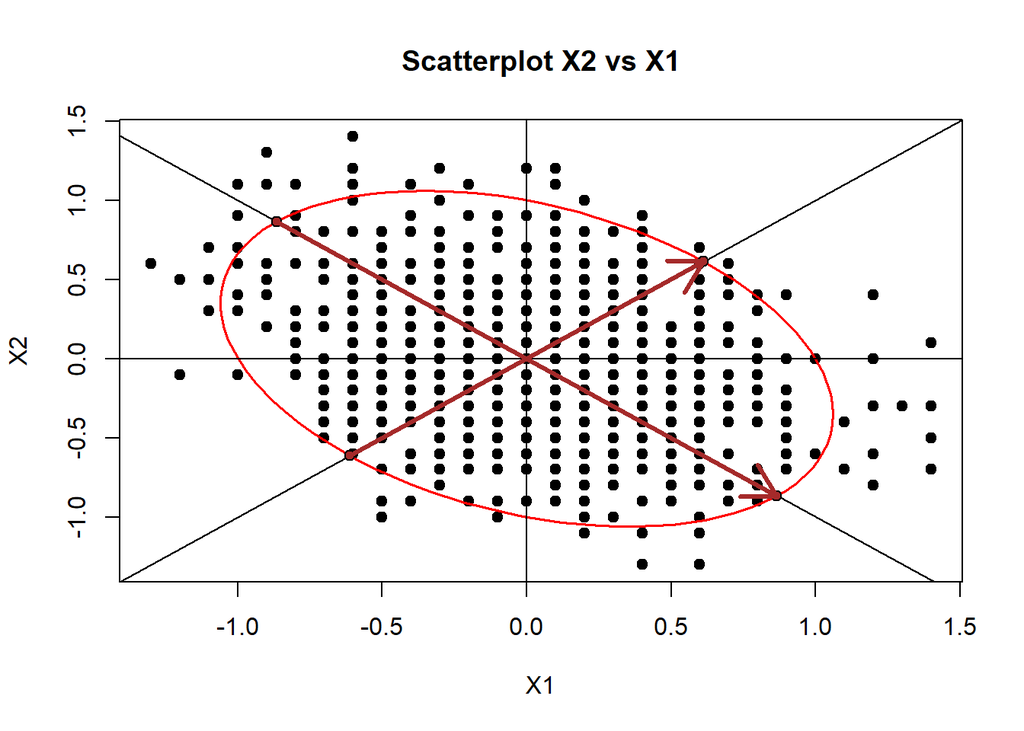

```r
arrows(x[1,1],x[2,1],x[1,2],x[2,2],code=2,col="brown",lwd=3)

arrows(x[1,3],x[2,3],x[1,4],x[2,4],code=2,col="brown",lwd=3)
```

```r
solve(Sigma)
```

```
##      [,1] [,2]
## [1,]    6    2
## [2,]    2    6
```

```r
eigen(Sigma)
```

```
## eigen() decomposition
## $values
## [1] 0.250 0.125
##
## $vectors
##            [,1]       [,2]
## [1,] -0.7071068 -0.7071068
## [2,]  0.7071068 -0.7071068
```

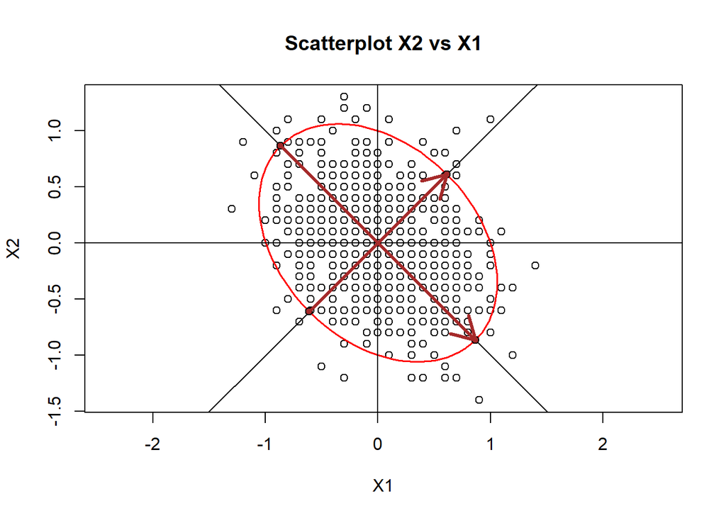

```r
set.seed(4567)

norm_samplev2<- matrix(NA, nrow=N, ncol=4)
for (i in (1:N)){
  M<-rmultinom(1,size=n,prob=c(1/4,1/4,1/4,1/4))
  norm_samplev2[i,]<-(M/n - pi_0)*sqrt(n)
}
Xv2 <- norm_samplev2[,1:3]
mu = c(0,0)
Sigma = matrix( c(3/16 , -1/16, -1/16,3/16) ,nrow=2 , ncol=2)
plot(Xv2[,1],Xv2[,2], xlab="X1", ylab = "X2", main="Scatterplot X2 vs X1", asp=1)
lines(ellipse(x=Sigma,centre=mu,level=0.95),col="red",lwd=1.5)
abline(a = a , b=b)
abline(a= a2, b=b2)
abline(h=0,v=0)
points(x[1,],x[2,],pch=21,bg="brown")


arrows(x[1,1],x[2,1],x[1,2],x[2,2],code=2,col="brown",lwd=3)

arrows(x[1,3],x[2,3],x[1,4],x[2,4],code=2,col="brown",lwd=3)
```

```r
set.seed(4567)

M<-rmultinom(N,size=n,prob=c(1/4,1/4,1/4,1/4)) / n
norm_samplev2<-(M/n - pi_0)*sqrt(n)
cor(norm_sample)
```

```
##            [,1]       [,2]       [,3]       [,4]
## [1,]  1.0000000 -0.3292591 -0.3326393 -0.3230808
## [2,] -0.3292591  1.0000000 -0.3534907 -0.3402687
## [3,] -0.3326393 -0.3534907  1.0000000 -0.3208655
## [4,] -0.3230808 -0.3402687 -0.3208655  1.0000000
```

## punto 5

5.Find the conditional distributions of $(X_1, X_2) \mid X_3 = x_3$ and of $X_3 \mid (X_1 = x_1, X_2 = x_2)$.

Given a Gaussian random vector we know that conditioning on it the conditioned vector is still Gaussian with parameters :

$$\begin{align}
\overline{\mu} &= \mu_1 + \Sigma_{12}\Sigma_{22}^{-1}(a-\mu_2) \\
\overline{\Sigma}&= \Sigma_{11} -
\Sigma_{12}\Sigma_{22}^{-1}\Sigma_{21}
\end{align}$$

We know that $(X_{1},X_{2},X_{3}) \sim \mathcal{N}_3(\underline{0}, \Sigma)$ where

$$\Sigma=
\begin{pmatrix}
\frac{3}{16} & -\frac{1}{16} & -\frac{1}{16} \\
-\frac{1}{16} & \frac{3}{16} & -\frac{1}{16} \\
-\frac{1}{16} & -\frac{1}{16} & \frac{3}{16}
\end{pmatrix}$$

$$\left(
\begin{array}{cc|c}
\frac{3}{16} & -\frac{1}{16} & -\frac{1}{16}\\
-\frac{1}{16} & \frac{3}{16} & -\frac{1}{16} \\ \hline
-\frac{1}{16} & -\frac{1}{16} & \frac{3}{16}
\end{array}
\right) =
\left(\begin{array}{c|cc}
\Large\Sigma _{11} & \begin{matrix} \Sigma_{12} \\
& \end{matrix} \\ \hline
\begin{matrix} \Sigma_{21} & \end{matrix} & \Sigma _{22}
\end{array}\right)$$

5.1 We need to find the distribution of $(X_1,X_2)|X_3=x_3 \sim \mathcal{N}_2(\mu_{12|3}, \Sigma_{12|3})$ .

So now we have to apply the formula above adapting the notation to our conditioned vector.

The mean vector is:

$$\begin{align}
\mu_{12|3} & = \mu_{12} + \Sigma_{12}\Sigma_{22}^{-1}(x_3-\mu_3)
\\
& =\begin{pmatrix}
\mu_{1} \\
\mu_{2}
\end{pmatrix}+\begin{pmatrix}
-\frac{1}{16} \\
-\frac{1}{16}
\end{pmatrix} \frac{16}{3} (x_{3}-\mu_{3}) \\
&= \begin{pmatrix}
0 \\
0
\end{pmatrix} + \begin{pmatrix}
-\frac{1}{3} \\
-\frac{1}{3}
\end{pmatrix}x_{3} = \begin{pmatrix}
-\frac{1}{3}x_{3} \\
- \frac{1}{3}x_{3}
\end{pmatrix}
\end{align}$$

$$\begin{align}
\Sigma _{12|3} & = \Sigma _{11}-\Sigma_{12}\Sigma
_{22}^{-1}\Sigma _{21} \\
& = \begin{pmatrix}
\frac{3}{16} & -\frac{1}{16} \\
-\frac{1}{16} & \frac{3}{16}
\end{pmatrix} - \begin{pmatrix}
-\frac{1}{16} \\
-\frac{1}{16}
\end{pmatrix} \frac{16}{3}\begin{pmatrix}
-\frac{1}{16} & -\frac{1}{16}
\end{pmatrix} \\
& =\begin{pmatrix}
\frac{3}{16} & -\frac{1}{16} \\
-\frac{1}{16} & \frac{3}{16}
\end{pmatrix} - \begin{pmatrix}
\frac{1}{48} & \frac{1}{48} \\
\frac{1}{48} & \frac{1}{48}
\end{pmatrix} \\
& = \begin{pmatrix}
\frac{1}{6} & -\frac{1}{12} \\
-\frac{1}{12} & \frac{1}{6}
\end{pmatrix}.
\end{align}$$

So a the end
$$(X_{1},X_{2})|X_{3}=x_{3} \sim \mathcal{N}_{2}\left( \begin{bmatrix}
-\frac{1}{3}x_{3} \\
- \frac{1}{3}x_{3}
\end{bmatrix}, \begin{bmatrix}
\frac{1}{6} & -\frac{1}{12} \\
-\frac{1}{12} & \frac{1}{6}
\end{bmatrix}\right).$$
5.2 We now have to find the gaussian random variable:
$$X_{3}|(X_{1}=x_{1},X_{2}=x_{2}) \sim \mathcal{N}_{1} ( \mu_{3|12},
\Sigma _{3|12}).$$

Now we get the mean:

$$\begin{align}
\mu_{3|1,2} & = \mu_{3}+\Sigma_{12}\Sigma _{11}^{-1}\begin{pmatrix}
x_{1}-\mu_{1} \\
x_{2}-\mu_{2}
\end{pmatrix} \\
& =0+\begin{pmatrix}
-\frac{1}{16} & -\frac{1}{16}
\end{pmatrix} 32\begin{pmatrix}
\frac{3}{16} & \frac{1}{16} \\
\frac{1}{16} & \frac{3}{16}
\end{pmatrix}\begin{pmatrix}
x_{1} \\
x_{2} \end{pmatrix} \\
& =\begin{pmatrix}
-\frac{1}{16} & -\frac{1}{16}
\end{pmatrix}\underbrace{ \begin{pmatrix}
6 & 2 \\
2 & 6
\end{pmatrix} }_{ \Sigma _{11 }^{-1} }\begin{pmatrix}
x_{1} \\
x_{2}\end{pmatrix} \\
& = \begin{pmatrix}
-\frac{1}{2} &
-\frac{1}{2}
\end{pmatrix}\begin{pmatrix}
x_{1} \\
x_{2}
\end{pmatrix} \\
& = -\frac{1}{2}x_{1}-\frac{1}{2}x_{2}
\end{align}$$

And variance:

$$\begin{align}
\Sigma _{3|12} & = \Sigma_{22} -\Sigma _{21}\Sigma _{11}^{-1}\Sigma
_{12} \\
& = \frac{3}{16} - \begin{pmatrix}
-\frac{1}{16} & -\frac{1}{16}
\end{pmatrix}\begin{pmatrix}
6 & 2 \\
2 & 6
\end{pmatrix} \begin{pmatrix}
-\frac{1}{16} \\
-\frac{1}{16}
\end{pmatrix} \\
& =\frac{3}{16}- \begin{pmatrix}
-\frac{1}{2} &
-\frac{1}{2}
\end{pmatrix}\begin{pmatrix}
-\frac{1}{16} \\
-\frac{1}{16}
\end{pmatrix} \\
& =\frac{3}{16} - \frac{1}{16} = \frac{1}{8}
\end{align}$$

So at the end:
$$X_{3}|(X_{1}=x_{1},X_{2}=x_{2}) \sim \mathcal{N}\left(
-\frac{1}{2}x_{1}-\frac{1}{2}x_{2}, \frac{1}{8} \right)$$